# Replication of Boutonnet & Lupyan, 2015

```r
library(readr)
library(dplyr)
library(ggplot2)
library(lme4)
library(lmerTest)
library(tidyr)
library(patchwork)
library(brms)
```

```r
set.seed(12604)
```

```r
options(dplyr.summarise.inform = FALSE)
```

# Behavioral Data

```r
behavioral.data <- read_csv('data/behavioral/generated/behavioral_data.csv') %>%
  mutate(participant_id = factor(participant_id))
```

## Accuracy

Boutonnet & Lupyan found that participants were (1) highly accurate overall (95-97%) and (2) more accurate at label trials than sound trials. We report accuracy by condition here as a comparison.

```r
accuracy.data <- behavioral.data %>%
  filter(phase == "test") %>%
  group_by(participant_id, audio_type) %>%
  summarize(accuracy = mean(correct)*100) %>%
  group_by(audio_type) %>%
  summarize(M=mean(accuracy), SD=sd(accuracy), SE=SD / sqrt(n()))

accuracy.data
```

| audio_type | M | SD | SE |
| --- | --- | --- | --- |
| label | 97.09714 | 3.142637 | 0.5312026 |
| sound | 96.12571 | 3.298158 | 0.5574905 |

Overall accuracy in our sample is quite high, as well. The range is similar to Boutonnet & Lupyan’s reported accuracy.

Next we conduct a paired-sample t-test to determine if there is a statistically significant accuracy advantage for label trials over sound trials.

```r
accuracy.data <- behavioral.data %>%
  filter(phase == "test") %>%
  group_by(participant_id, audio_type) %>%
  summarize(accuracy = mean(correct)*100)
t.test(accuracy ~ audio_type, data=accuracy.data, paired=T)
```

```
    Paired t-test

data:  accuracy by audio_type
t = 2.9986, df = 34, p-value = 0.005044
alternative hypothesis: true difference in means is not equal to 0
95 percent confidence interval:
 0.3130604 1.6297967
sample estimates:
mean of the differences
              0.9714286
```

We also find that participants are slightly more accurate in label trials than sound trials.

## Response Times

### Visualizations

We start our analysis of response time data by reproducing Boutonnet & Lupyan’s Figure 1.

```r
rt.data <- behavioral.data %>%
  filter(phase=="test", correct==TRUE) %>%
  group_by(participant_id, match_type, audio_type) %>%
  summarize(participant.avg.rt = mean(rt)) %>%
  group_by(match_type, audio_type) %>%
  summarize(M=mean(participant.avg.rt), SE=sd(participant.avg.rt)/sqrt(n()))
```

```r
rt.full.dist.data <- behavioral.data %>%
  filter(phase=="test", correct==TRUE) %>%
  group_by(participant_id, match_type, audio_type) %>%
  summarize(participant.avg.rt = mean(rt)) %>%
  pivot_wider
```

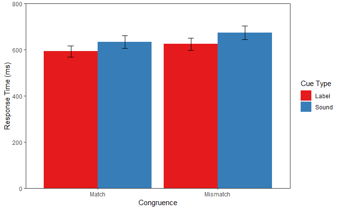

```r
behavioral.figure <- ggplot(rt.data, aes(x=match_type, y=M, ymin=M-SE, ymax=M+SE, fill=audio_type))+
  geom_bar(stat="identity", position=position_dodge(width=0.9), orientation="x")+
  geom_errorbar(position=position_dodge(width=0.9), width=0.1) +
  labs(x="Congruence", y="Response Time (ms)", fill="Cue Type")+
  scale_fill_brewer(type="qual", palette = "Set1", labels=c("Label", "Sound"))+
  scale_x_discrete(labels=c("Match", "Mismatch"))+
  scale_y_continuous(limits=c(0,800),expand=c(0,0))+
  theme_bw(base_size = 11)+
  theme(panel.grid=element_blank())

ggsave("figures/figure1-behavioral.png", behavioral.figure, height = 2.5, width=3.75, units="in", dpi=300)

behavioral.figure
```

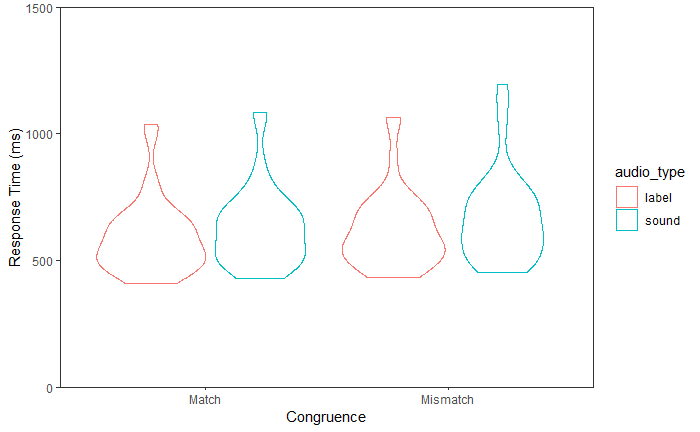

```r
behavioral.figure.full <- ggplot(rt.full.dist.data, aes(x=match_type, y=participant.avg.rt, color=audio_type))+
  geom_violin()+
  labs(x="Congruence", y="Response Time (ms)", fill="Cue Type")+
  scale_fill_brewer(type="qual", palette = "Set1", labels=c("Label", "Sound"))+
  scale_x_discrete(labels=c("Match", "Mismatch"))+
  scale_y_continuous(limits=c(0,1500),expand=c(0,0))+
  theme_bw(base_size = 11)+
  theme(panel.grid=element_blank())

#ggsave("figures/figure1-behavioral.png", behavioral.figure, height = 2.5, width=3.75, units="in", dpi=300)

behavioral.figure.full
```

Comparing with the original, the relative pattern of results across conditions is very similar. Our response times seem to be longer, with the fastest condition around 600ms instead of the original’s <500ms. This could be a consequence of using different experiment software to record response times.

### Pre-registered Replication Analysis

As in Boutonnet & Lupyan, we use a linear mixed effects model to examine whether cue type and congruence reliably predict response times. The model predicts response times from the main effects of cue type and congruence, plus their interaction. It includes random effects for cue type and congruence by subject.

```r
rt.model.data <- behavioral.data %>%
  filter(phase=="test", correct==TRUE) %>%
  select(participant_id, audio_type, match_type, rt) %>%
  mutate(audio_type = factor(audio_type), match_type = factor(match_type))

rt.model <- lmer(rt ~ audio_type*match_type + (audio_type + match_type|participant_id), data=rt.model.data,
                 control=lmerControl(optimizer = "bobyqa"))

summary(rt.model)
```

```
Linear mixed model fit by REML. t-tests use Satterthwaite's method ['lmerModLmerTest']
Formula: rt ~ audio_type * match_type + (audio_type + match_type | participant_id)
   Data: rt.model.data
Control: lmerControl(optimizer = "bobyqa")

REML criterion at convergence: 237460.4

Scaled residuals:
    Min      1Q  Median      3Q     Max
-2.5329 -0.4396 -0.1554  0.2211 22.3992

Random effects:
 Groups         Name                Variance Std.Dev. Corr
 participant_id (Intercept)         19875.3  140.98
                audio_typesound       577.8   24.04   0.65
                match_typenon-match  1355.3   36.81   0.27 0.63
 Residual                           72809.4  269.83
Number of obs: 16907, groups:  participant_id, 35

Fixed effects:
                                     Estimate Std. Error        df t value Pr(>|t|)
(Intercept)                           592.659     24.188    34.504  24.502  < 2e-16 ***
audio_typesound                        40.673      7.152    78.240   5.687 2.14e-07 ***
match_typenon-match                    31.773      8.545    58.069   3.718 0.000454 ***
audio_typesound:match_typenon-match     8.082      8.302 16807.585   0.973 0.330323
---
Signif. codes:  0 ‘***’ 0.001 ‘**’ 0.01 ‘*’ 0.05 ‘.’ 0.1 ‘ ’ 1

Correlation of Fixed Effects:
            (Intr) ad_typ mtch_-
audi_typsnd  0.264
mtch_typnn-  0.109  0.541
ad_typsn:_-  0.086 -0.583 -0.483
```

We find that participants are faster responding when the cue is a label (b=40.6) and faster when the trial is match (b=31.7). We find no significant interaction between cue type and congruence.

This pattern matches the behavioral findings of Boutonnet & Lupyan, indicating a positive replication.

### Exploratory BRMS models

```r
rt.brms.model.data <- behavioral.data %>%
  filter(phase=="test", correct==TRUE) %>%
  select(participant_id, audio_type, match_type, rt, stimulus) %>%
  mutate(audio_type = factor(audio_type), match_type = factor(match_type), stimulus=factor(stimulus))

rt.brms.model.formula <- bf(
  rt ~ audio_type * match_type + (audio_type * match_type | participant_id) + (audio_type * match_type | stimulus)
)

get_prior(rt.brms.model.formula,  data = rt.brms.model.data)
```

```
                    prior     class                                coef          group resp dpar nlpar bound       source
                   (flat)         b                                                                               default
                   (flat)         b                     audio_typesound                                      (vectorized)
                   (flat)         b audio_typesound:match_typenonMmatch                                      (vectorized)
                   (flat)         b                 match_typenonMmatch                                      (vectorized)
                   lkj(1)       cor                                                                               default
                   lkj(1)       cor                                     participant_id                       (vectorized)
                   lkj(1)       cor                                           stimulus                       (vectorized)
 student_t(3, 552, 158.3) Intercept                                                                               default
   student_t(3, 0, 158.3)        sd                                                                               default
   student_t(3, 0, 158.3)        sd                                     participant_id                       (vectorized)
   student_t(3, 0, 158.3)        sd                     audio_typesound participant_id                       (vectorized)
   student_t(3, 0, 158.3)        sd audio_typesound:match_typenonMmatch participant_id                       (vectorized)
   student_t(3, 0, 158.3)        sd                           Intercept participant_id                       (vectorized)
   student_t(3, 0, 158.3)        sd                 match_typenonMmatch participant_id                       (vectorized)
   student_t(3, 0, 158.3)        sd                                           stimulus                       (vectorized)
   student_t(3, 0, 158.3)        sd                     audio_typesound       stimulus                       (vectorized)
   student_t(3, 0, 158.3)        sd audio_typesound:match_typenonMmatch       stimulus                       (vectorized)
   student_t(3, 0, 158.3)        sd                           Intercept       stimulus                       (vectorized)
   student_t(3, 0, 158.3)        sd                 match_typenonMmatch       stimulus                       (vectorized)
   student_t(3, 0, 158.3)     sigma                                                                               default
```

```r
rt.brms.model.priors.BL <- c(
  set_prior("normal(10.4,1.93)", class="b", coef="audio_typesound"),
  set_prior("normal(30,1.94)", class="b", coef="match_typenonMmatch"),
  set_prior("normal(0,10.4)", class="b", coef="audio_typesound:match_typenonMmatch")
)

rt.brms.model.priors.MI <- c(
  set_prior("normal(0, 60)", class="b")
)

rt.brms.model.BL <- brm(
  formula = rt.brms.model.formula,
  data = rt.brms.model.data,
  prior = rt.brms.model.priors.BL,
  warmup = 1000,
  iter = 4000,
  save_pars = save_pars(group=FALSE),
  sample_prior = TRUE,
  chains = 8,
  cores = 8,
  file = "data/brms_fits/rt_model_BL"
)

rt.brms.model.MI <- brm(
  formula = rt.brms.model.formula,
  data = rt.brms.model.data,
  prior = rt.brms.model.priors.MI,
  warmup = 1000,
  iter = 4000,
  save_pars = save_pars(group=FALSE),
  sample_prior = TRUE,
  chains = 8,
  cores = 8,
  file = "data/brms_fits/rt_model_MI"
)
```

#### Analysis of MI model

With the brms maximal random effects model we can look at the parameter estimates on the population-level parameters:

```r
summary(rt.brms.model.MI)
```

```
 Family: gaussian
  Links: mu = identity; sigma = identity
Formula: rt ~ audio_type * match_type + (audio_type * match_type | participant_id) + (audio_type * match_type | stimulus)
   Data: rt.brms.model.data (Number of observations: 16907)
Samples: 8 chains, each with iter = 4000; warmup = 1000; thin = 1;
         total post-warmup samples = 24000

Group-Level Effects:
~participant_id (Number of levels: 35)
                                                             Estimate Est.Error l-95% CI u-95% CI Rhat Bulk_ESS Tail_ESS
sd(Intercept)                                                  147.25     18.60   115.62   188.24 1.00     5090     9550
sd(audio_typesound)                                             22.75      7.41     7.79    37.41 1.00     6905     4717
sd(match_typenonMmatch)                                         36.95      7.64    23.04    53.21 1.00    11399    13398
sd(audio_typesound:match_typenonMmatch)                         12.69      8.63     0.56    32.17 1.00     8482    12069
cor(Intercept,audio_typesound)                                   0.47      0.23    -0.05     0.85 1.00    18189    16481
cor(Intercept,match_typenonMmatch)                               0.17      0.20    -0.25     0.54 1.00    17764    18330
cor(audio_typesound,match_typenonMmatch)                         0.41      0.27    -0.20     0.84 1.00     4204     4318
cor(Intercept,audio_typesound:match_typenonMmatch)               0.34      0.39    -0.58     0.90 1.00    24612    17673
cor(audio_typesound,audio_typesound:match_typenonMmatch)         0.18      0.41    -0.67     0.86 1.00    25434    18805
cor(match_typenonMmatch,audio_typesound:match_typenonMmatch)     0.16      0.40    -0.67     0.85 1.00    20155    19429

~stimulus (Number of levels: 50)
                                                             Estimate Est.Error l-95% CI u-95% CI Rhat Bulk_ESS Tail_ESS
sd(Intercept)                                                   29.65      6.27    18.38    42.66 1.00     8610    14649
sd(audio_typesound)                                             37.12      8.44    21.03    54.14 1.00     6631    10509
sd(match_typenonMmatch)                                         17.33      8.54     1.55    34.16 1.00     6169     6988
sd(audio_typesound:match_typenonMmatch)                         39.66     11.34    16.86    61.71 1.00     6414     6618
cor(Intercept,audio_typesound)                                   0.36      0.26    -0.15     0.84 1.00     6364     8214
cor(Intercept,match_typenonMmatch)                              -0.68      0.29    -0.97     0.16 1.00    10083    11193
cor(audio_typesound,match_typenonMmatch)                        -0.22      0.35    -0.84     0.49 1.00    10560    15158
cor(Intercept,audio_typesound:match_typenonMmatch)              -0.53      0.25    -0.91     0.01 1.00     7932    11009
cor(audio_typesound,audio_typesound:match_typenonMmatch)        -0.73      0.18    -0.95    -0.26 1.00     9339    11783
cor(match_typenonMmatch,audio_typesound:match_typenonMmatch)     0.25      0.36    -0.48     0.86 1.00     8412    15392

Population-Level Effects:
                                    Estimate Est.Error l-95% CI u-95% CI Rhat Bulk_ESS Tail_ESS
Intercept                             590.72     25.07   541.31   639.62 1.00     1968     4679
audio_typesound                        40.07      8.73    22.84    56.94 1.00    14356    17860
match_typenonMmatch                    30.25      8.95    12.42    47.86 1.00    17704    18522
audio_typesound:match_typenonMmatch     8.15     10.18   -11.80    28.02 1.00    21151    19478

Family Specific Parameters:
      Estimate Est.Error l-95% CI u-95% CI Rhat Bulk_ESS Tail_ESS
sigma   267.77      1.47   264.94   270.65 1.00    58851    17380

Samples were drawn using sampling(NUTS). For each parameter, Bulk_ESS
and Tail_ESS are effective sample size measures, and Rhat is the potential
scale reduction factor on split chains (at convergence, Rhat = 1).
```

#### Analysis of BL model

```r
summary(rt.brms.model.BL)
```

```
 Family: gaussian
  Links: mu = identity; sigma = identity
Formula: rt ~ audio_type * match_type + (audio_type * match_type | participant_id) + (audio_type * match_type | stimulus)
   Data: rt.brms.model.data (Number of observations: 16907)
Samples: 8 chains, each with iter = 4000; warmup = 1000; thin = 1;
         total post-warmup samples = 24000

Group-Level Effects:
~participant_id (Number of levels: 35)
                                                             Estimate Est.Error l-95% CI u-95% CI Rhat Bulk_ESS Tail_ESS
sd(Intercept)                                                  148.78     19.39   116.21   191.97 1.00     4497     8144
sd(audio_typesound)                                             28.77      8.11    13.01    45.34 1.00     5791     5160
sd(match_typenonMmatch)                                         36.67      7.34    23.27    52.21 1.00    11177    13653
sd(audio_typesound:match_typenonMmatch)                         11.87      8.30     0.48    30.96 1.00     8260    11646
cor(Intercept,audio_typesound)                                   0.47      0.22    -0.02     0.84 1.00     6491    11876
cor(Intercept,match_typenonMmatch)                               0.18      0.20    -0.24     0.55 1.00    15594    17205
cor(audio_typesound,match_typenonMmatch)                         0.39      0.25    -0.17     0.81 1.00     5348     8007
cor(Intercept,audio_typesound:match_typenonMmatch)               0.31      0.40    -0.61     0.90 1.00    23082    17667
cor(audio_typesound,audio_typesound:match_typenonMmatch)         0.16      0.42    -0.69     0.86 1.00    23217    17820
cor(match_typenonMmatch,audio_typesound:match_typenonMmatch)     0.15      0.42    -0.70     0.85 1.00    19508    19340

~stimulus (Number of levels: 50)
                                                             Estimate Est.Error l-95% CI u-95% CI Rhat Bulk_ESS Tail_ESS
sd(Intercept)                                                   29.34      6.23    18.05    42.44 1.00     8627    13112
sd(audio_typesound)                                             42.18      8.71    25.71    60.01 1.00     5783     9072
sd(match_typenonMmatch)                                         16.87      8.39     1.55    33.66 1.00     6566     6505
sd(audio_typesound:match_typenonMmatch)                         41.21     11.06    19.36    62.83 1.00     6826     8628
cor(Intercept,audio_typesound)                                   0.30      0.26    -0.20     0.78 1.00     4857     7953
cor(Intercept,match_typenonMmatch)                              -0.66      0.29    -0.97     0.18 1.00    10349    11256
cor(audio_typesound,match_typenonMmatch)                        -0.21      0.35    -0.83     0.51 1.00     9171    14540
cor(Intercept,audio_typesound:match_typenonMmatch)              -0.51      0.25    -0.90     0.04 1.00     6683     9548
cor(audio_typesound,audio_typesound:match_typenonMmatch)        -0.74      0.17    -0.95    -0.32 1.00     9840    13893
cor(match_typenonMmatch,audio_typesound:match_typenonMmatch)     0.24      0.36    -0.50     0.86 1.00     7242    12871

Population-Level Effects:
                                    Estimate Est.Error l-95% CI u-95% CI Rhat Bulk_ESS Tail_ESS
Intercept                             570.15     26.75   516.61   621.59 1.01     1563     3500
audio_typesound                        11.98      1.91     8.21    15.76 1.00    37249    18460
match_typenonMmatch                    29.73      1.87    26.07    33.40 1.00    37489    18357
audio_typesound:match_typenonMmatch    15.24      6.95     1.52    28.49 1.00    13241    17401

Family Specific Parameters:
      Estimate Est.Error l-95% CI u-95% CI Rhat Bulk_ESS Tail_ESS
sigma   267.75      1.46   264.91   270.70 1.00    51267    16166

Samples were drawn using sampling(NUTS). For each parameter, Bulk_ESS
and Tail_ESS are effective sample size measures, and Rhat is the potential
scale reduction factor on split chains (at convergence, Rhat = 1).
```

Has our belief in the alternative hypothesis been strengthened?

```r
rt.h1 <- hypothesis(rt.brms.model.BL, "audio_typesound = 0")
rt.h1
```

```
Hypothesis Tests for class b:
```

| Hypothesis | Estimate | Est.Error | CI.Lower | CI.Upper | Evid.Ratio | Post.Prob | Star |
| --- | --- | --- | --- | --- | --- | --- | --- |
| (audio_typesound) = 0 | 11.98 | 1.91 | 8.21 | 15.76 | 0 | 0 | * |

```
---
'CI': 90%-CI for one-sided and 95%-CI for two-sided hypotheses.
'*': For one-sided hypotheses, the posterior probability exceeds 95%;
for two-sided hypotheses, the value tested against lies outside the 95%-CI.
Posterior probabilities of point hypotheses assume equal prior probabilities.
```

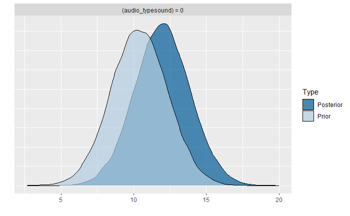

```r
plot(rt.h1)
```

# EEG Data

## Loading Data and Preprocessing

To make the data size manageable within this notebook, we perform a lot of preprocessing steps on the raw data in other R scripts located in the `preprocessing` folder. The end result of this pre-processing pipeline is a set of two files.

The `all_averaged.csv` file contains subject-level averages (averaging across trials) for all the relevant electrodes in each cell of the design. It preserves temporal information to enable plotting of wave forms.

The `single_trial_eeg_behavior.csv` contains collapsed EEG information (average amplitude, amplitude peak time) and behavioral data (RT) for each trial.

```r
eeg.averaged.data <- read_csv('data/eeg/generated/all_averaged.csv') %>%
  mutate(electrode = factor(electrode))
eeg.single.trial.data <- read_csv('data/eeg/generated/single_trial_eeg_behavioral.csv')
```

Calculate how many good segments per subject

```r
subject.level.segment.count <- eeg.single.trial.data %>% filter(component=="N4") %>% group_by(subject) %>% summarize(n=n())

subject.level.segment.count %>% summarize(M=mean(n),SD=sd(n),Min=min(n), Max=max(n))
```

| M | SD | Min | Max |
| --- | --- | --- | --- |
| 403.0857 | 74.12643 | 213 | 485 |

## P1 and P2 waveforms

### Visualizations of P1 and P2

First we look at the P1 and P2 separately for each cue type and hemisphere.

```r
p1.p2.audio.data <- eeg.averaged.data %>%
  filter(location == "occipital") %>%
  group_by(subject, hemisphere, audio, t) %>%
  summarize(subject.voltage = mean(voltage)) %>%
  group_by(hemisphere, audio, t) %>%
  summarize(M=mean(subject.voltage), SE = sd(subject.voltage)/sqrt(n()))
```

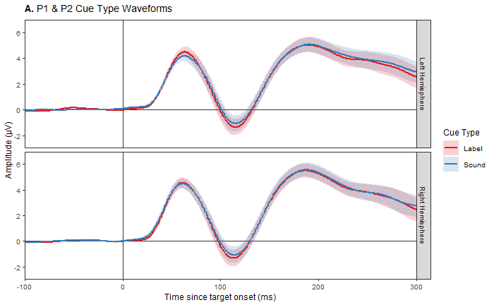

```r
panel.a <- ggplot(p1.p2.audio.data, aes(x=t, y=M, ymin=M-SE, ymax=M+SE, color=audio, fill=audio))+
  geom_vline(xintercept = 0, color="grey20")+
  geom_hline(yintercept = 0, color="grey20")+
  geom_ribbon(alpha=0.2, color=NA)+
  geom_line(size=0.75)+
  facet_grid(hemisphere~., labeller = labeller(hemisphere=c(left="Left Hemisphere", right="Right Hemisphere")))+
  scale_x_continuous(expand=c(0,0))+
  scale_y_continuous(breaks=c(-2,0,2,4,6))+
  labs(title=expression(paste(bold("A.")," P1 & P2 Cue Type Waveforms")), x="Time since target onset (ms)", y="Amplitude (\U003BCV)", fill="Cue Type", color="Cue Type")+
  scale_color_brewer(type="qual", palette = "Set1", labels=c("Label", "Sound"))+
  scale_fill_brewer(type="qual", palette = "Set1", labels=c("Label", "Sound"))+
  theme_bw(base_size = 9) +
  coord_cartesian(xlim=c(-100,300), ylim=c(-2.5,6.5))+
  theme(panel.spacing.x = unit(1.5, "lines"), panel.grid = element_blank())

panel.a
```

Next we look at the waveforms grouped by congruence and hemisphere.

```r
p1.p2.congruence.data <- eeg.averaged.data %>%
  filter(location == "occipital", t %in% -100:300) %>%
  group_by(subject, hemisphere, congruence, t) %>%
  summarize(subject.voltage = mean(voltage)) %>%
  group_by(hemisphere, congruence, t) %>%
  summarize(M=mean(subject.voltage), SE = sd(subject.voltage)/sqrt(n()))
```

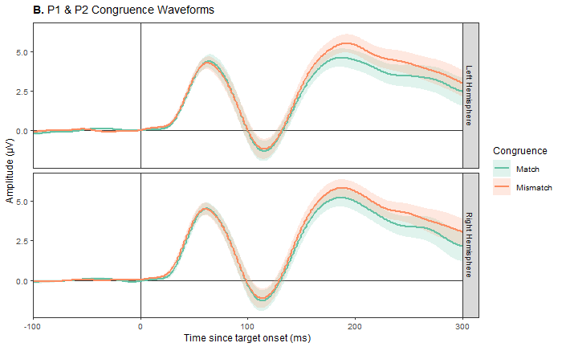

```r
panel.b <- ggplot(p1.p2.congruence.data, aes(x=t, y=M, ymin=M-SE, ymax=M+SE, color=congruence, fill=congruence))+
  geom_vline(xintercept = 0, color="grey20")+
  geom_hline(yintercept = 0, color="grey20")+
  geom_ribbon(alpha=0.2, color=NA)+
  geom_line(size=0.75)+
  facet_grid(hemisphere~., labeller = labeller(hemisphere=c(left="Left Hemisphere", right="Right Hemisphere")))+
  scale_x_continuous(limits=c(-100,300), expand=c(0,0))+
  labs(title=expression(paste(bold("B.")," P1 & P2 Congruence Waveforms")), x="Time since target onset (ms)", y="Amplitude (\U003BCV)", fill="Congruence", color="Congruence")+
  scale_color_brewer(type="qual", palette = "Set2", labels=c("Match", "Mismatch"))+
  scale_fill_brewer(type="qual", palette = "Set2", labels=c("Match", "Mismatch"))+
  theme_bw(base_size = 9) +
  theme(panel.grid = element_blank())

panel.b
```

### Pre-registered Replication Analysis

Following Boutonnet & Lupyan, we look for differences in mean amplitude of the P1 based on hemisphere, cue type, and congruence. We use a linear mixed effects model containing the full interaction of these fixed effects, plus random effects for each factor by subject.

```r
p1.model.data <- eeg.single.trial.data %>%
  filter(component == "P1")

p1.model <- lmer(mean.amplitude ~ hemisphere*audio*congruence + (hemisphere + audio + congruence|subject), data=p1.model.data, control=lmerControl(optimizer="bobyqa"))

summary(p1.model)
```

```
Linear mixed model fit by REML. t-tests use Satterthwaite's method ['lmerModLmerTest']
Formula: mean.amplitude ~ hemisphere * audio * congruence + (hemisphere +      audio + congruence | subject)
   Data: p1.model.data
Control: lmerControl(optimizer = "bobyqa")

REML criterion at convergence: 193237.2

Scaled residuals:
     Min       1Q   Median       3Q      Max
-19.0584  -0.4605  -0.0024   0.4629  15.5844

Random effects:
 Groups   Name                Variance Std.Dev. Corr
 subject  (Intercept)          4.95298 2.2255
          hemisphereright      3.80459 1.9505   -0.50
          audiosound           0.39890 0.6316   -0.09 -0.25
          congruencenon-match  0.05908 0.2431   -0.61  0.32  0.21
 Residual                     54.65898 7.3932
Number of obs: 28216, groups:  subject, 35

Fixed effects:
                                                 Estimate Std. Error         df t value Pr(>|t|)
(Intercept)                                        3.0098     0.3968    37.8315   7.585 4.15e-09 ***
hemisphereright                                    0.1504     0.3748    49.5890   0.401 0.689855
audiosound                                         0.3250     0.2074   161.8169   1.567 0.119042
congruencenon-match                                0.4237     0.1807   359.9205   2.345 0.019568 *
hemisphereright:audiosound                        -0.1426     0.2507 28073.1363  -0.569 0.569381
hemisphereright:congruencenon-match               -0.2075     0.2487 28072.6349  -0.834 0.404060
audiosound:congruencenon-match                    -0.8456     0.2491 28095.1603  -3.395 0.000687 ***
hemisphereright:audiosound:congruencenon-match     0.5403     0.3522 28072.0816   1.534 0.124998
---
Signif. codes:  0 ‘***’ 0.001 ‘**’ 0.01 ‘*’ 0.05 ‘.’ 0.1 ‘ ’ 1

Correlation of Fixed Effects:
            (Intr) hmsphr audsnd cngrn- hmsph: hmsp:- adsn:-
hemsphrrght -0.523
audiosound  -0.235  0.089
cngrncnn-mt -0.351  0.296  0.445
hmsphrrght:  0.158 -0.334 -0.604 -0.347
hmsphrrgh:-  0.159 -0.337 -0.304 -0.688  0.504
adsnd:cngr-  0.159 -0.168 -0.609 -0.687  0.503  0.499
hmsphrrg::- -0.112  0.238  0.430  0.486 -0.712 -0.706 -0.707
```

The central result of Boutonnet & Lupyan was a main effect of cue type (`audiosound` in the above table). We find no main effect here. Numerically our result is in the opposite direction, with sound trials having non-significantly higher mean amplitudes in the P1 window.

We do, however, find an interaction between congruence and cue type. Replotting the data to visualize this effect produces these waveforms:

```r
p1.p2.follow.up.interaction.data <- eeg.averaged.data %>%
  filter(location == "occipital") %>%
  group_by(subject, congruence, audio, t) %>%
  summarize(subject.voltage = mean(voltage)) %>%
  group_by(congruence, audio, t) %>%
  summarize(M=mean(subject.voltage), SE = sd(subject.voltage)/sqrt(n()))
```

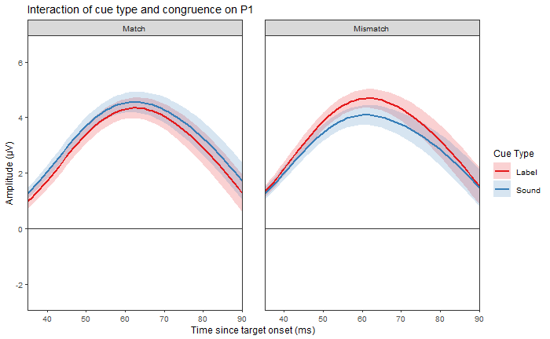

```r
ggplot(p1.p2.follow.up.interaction.data, aes(x=t, y=M, ymin=M-SE, ymax=M+SE, color=audio, fill=audio))+
  geom_vline(xintercept = 0, color="grey20")+
  geom_hline(yintercept = 0, color="grey20")+
  geom_ribbon(alpha=0.2, color=NA)+
  geom_line(size=0.75)+
  facet_grid(.~congruence, labeller = labeller(congruence=c(match="Match", `non-match`="Mismatch")))+
  scale_x_continuous(expand=c(0,0))+
  scale_y_continuous(breaks=c(-2,0,2,4,6))+
  labs(title="Interaction of cue type and congruence on P1", x="Time since target onset (ms)", y="Amplitude (\U003BCV)", fill="Cue Type", color="Cue Type")+
  scale_color_brewer(type="qual", palette = "Set1", labels=c("Label", "Sound"))+
  scale_fill_brewer(type="qual", palette = "Set1", labels=c("Label", "Sound"))+
  theme_bw(base_size = 9) +
  coord_cartesian(xlim=c(35,90), ylim=c(-2.5,6.5))+
  theme(panel.spacing.x = unit(1.5, "lines"), panel.grid = element_blank())
```

```r
p2.model.data <- eeg.single.trial.data %>%
  filter(component == "P2")

p2.model <- lmer(peak.amplitude ~ hemisphere*audio*congruence + (hemisphere + audio + congruence|subject), data=p2.model.data, control=lmerControl(optimizer="bobyqa"))

summary(p2.model)
```

```
Linear mixed model fit by REML. t-tests use Satterthwaite's method ['lmerModLmerTest']
Formula: peak.amplitude ~ hemisphere * audio * congruence + (hemisphere +      audio + congruence | subject)
   Data: p2.model.data
Control: lmerControl(optimizer = "bobyqa")

REML criterion at convergence: 162994.5

Scaled residuals:
     Min       1Q   Median       3Q      Max
-13.1918  -0.4796  -0.0116   0.4507  14.4039

Random effects:
 Groups   Name                Variance Std.Dev. Corr
 subject  (Intercept)          13.1012  3.6196
          hemisphereright       3.5363  1.8805  -0.47
          audiosound            0.5751  0.7583  -0.20  0.29
          congruencenon-match   0.9414  0.9703  -0.43  0.48  0.45
 Residual                     108.2455 10.4041
Number of obs: 21636, groups:  subject, 35

Fixed effects:
                                                 Estimate Std. Error         df t value Pr(>|t|)
(Intercept)                                        7.3918     0.6449    37.1417  11.462 9.30e-14 ***
hemisphereright                                    0.7316     0.4275    76.0135   1.711  0.09109 .
audiosound                                         0.7311     0.3151   234.5511   2.320  0.02120 *
congruencenon-match                                1.4197     0.3272   180.7065   4.339 2.38e-05 ***
hemisphereright:audiosound                        -0.2496     0.4037 21524.9441  -0.618  0.53640
hemisphereright:congruencenon-match               -0.4016     0.3990 21517.2946  -1.007  0.31418
audiosound:congruencenon-match                    -1.1067     0.4018 21529.1336  -2.754  0.00589 **
hemisphereright:audiosound:congruencenon-match     0.2900     0.5663 21512.1297   0.512  0.60866
---
Signif. codes:  0 ‘***’ 0.001 ‘**’ 0.01 ‘*’ 0.05 ‘.’ 0.1 ‘ ’ 1

Correlation of Fixed Effects:
            (Intr) hmsphr audsnd cngrn- hmsph: hmsp:- adsn:-
hemsphrrght -0.484
audiosound  -0.279  0.391
cngrncnn-mt -0.398  0.470  0.489
hmsphrrght:  0.157 -0.469 -0.648 -0.308
hmsphrrgh:-  0.158 -0.474 -0.324 -0.610  0.502
adsnd:cngr-  0.157 -0.237 -0.652 -0.606  0.508  0.497
hmsphrrg::- -0.112  0.334  0.462  0.430 -0.712 -0.704 -0.709
```

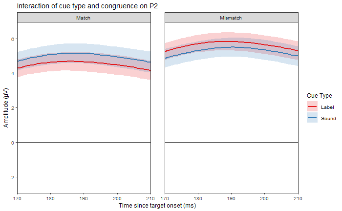

```r
ggplot(p1.p2.follow.up.interaction.data, aes(x=t, y=M, ymin=M-SE, ymax=M+SE, color=audio, fill=audio))+
  geom_vline(xintercept = 0, color="grey20")+
  geom_hline(yintercept = 0, color="grey20")+
  geom_ribbon(alpha=0.2, color=NA)+
  geom_line(size=0.75)+
  facet_grid(.~congruence, labeller = labeller(congruence=c(match="Match", `non-match`="Mismatch")))+
  scale_x_continuous(expand=c(0,0))+
  scale_y_continuous(breaks=c(-2,0,2,4,6))+
  labs(title="Interaction of cue type and congruence on P2", x="Time since target onset (ms)", y="Amplitude (\U003BCV)", fill="Cue Type", color="Cue Type")+
  scale_color_brewer(type="qual", palette = "Set1", labels=c("Label", "Sound"))+
  scale_fill_brewer(type="qual", palette = "Set1", labels=c("Label", "Sound"))+
  theme_bw(base_size = 9) +
  coord_cartesian(xlim=c(170,210), ylim=c(-2.5,6.5))+
  theme(panel.spacing.x = unit(1.5, "lines"), panel.grid = element_blank())
```

This shows the same pattern as the P1. Label trials have a higher amplitude only in mismatch trials.

Here we zoom out on these figures to capture both P1 and P2 in the same figure for inclusion in the manuscript.

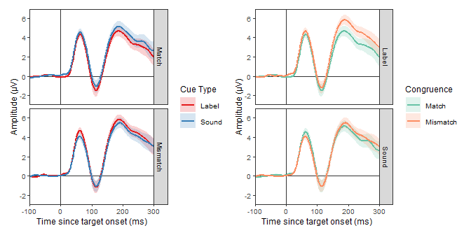

```r
p1.p2.interaction.plot.a <- ggplot(p1.p2.follow.up.interaction.data, aes(x=t, y=M, ymin=M-SE, ymax=M+SE, color=audio, fill=audio))+
  geom_vline(xintercept = 0, color="grey20")+
  geom_hline(yintercept = 0, color="grey20")+
  geom_ribbon(alpha=0.2, color=NA)+
  geom_line(size=0.75)+
  facet_grid(congruence~., labeller = labeller(congruence=c(match="Match", `non-match`="Mismatch")))+
  scale_x_continuous(expand=c(0,0))+
  scale_y_continuous(breaks=c(-2,0,2,4,6))+
  labs(title=NULL, x="Time since target onset (ms)", y="Amplitude (\U003BCV)", fill="Cue Type", color="Cue Type")+
  scale_color_brewer(type="qual", palette = "Set1", labels=c("Label", "Sound"))+
  scale_fill_brewer(type="qual", palette = "Set1", labels=c("Label", "Sound"))+
  theme_bw(base_size = 9) +
  coord_cartesian(xlim=c(-100,300),ylim=c(-2.5,6.5))+
  theme(panel.spacing.x = unit(1.5, "lines"), panel.grid = element_blank())

p1.p2.interaction.plot.b <- ggplot(p1.p2.follow.up.interaction.data, aes(x=t, y=M, ymin=M-SE, ymax=M+SE, color=congruence, fill=congruence))+
  geom_vline(xintercept = 0, color="grey20")+
  geom_hline(yintercept = 0, color="grey20")+
  geom_ribbon(alpha=0.2, color=NA)+
  geom_line(size=0.75)+
  facet_grid(audio~.)+
  facet_grid(audio~., labeller = labeller(audio=c(label="Label", sound="Sound")))+
  scale_x_continuous(expand=c(0,0))+
  scale_y_continuous(breaks=c(-2,0,2,4,6))+
  labs(title=NULL, x="Time since target onset (ms)", y="Amplitude (\U003BCV)", fill="Congruence", color="Congruence")+
  scale_color_brewer(type="qual", palette = "Set2", labels=c("Match", "Mismatch") )+
  scale_fill_brewer(type="qual", palette = "Set2", labels=c("Match", "Mismatch"))+
  theme_bw(base_size = 9) +
  coord_cartesian(xlim=c(-100,300),ylim=c(-2.5,6.5))+
  theme(panel.spacing.x = unit(1.5, "lines"), panel.grid = element_blank())

merged.fig.5 <- p1.p2.interaction.plot.a | p1.p2.interaction.plot.b

ggsave("figures/figure5-p1-p2-interaction.png", merged.fig.5, height = 3.5, width=7, units="in", dpi=300)

merged.fig.5
```

### Exploratory BRMS Models

```r
p1.model.data <- eeg.single.trial.data %>%
  filter(component == "P1")

p1.brms.model.formula <- bf(mean.amplitude ~ hemisphere*audio*congruence + (hemisphere*audio*congruence|subject) + (hemisphere* audio*congruence|stimulus))

get_prior(p1.brms.model.formula, data=p1.model.data)
```

```
                  prior     class                                           coef
                 (flat)         b
                 (flat)         b                                     audiosound
                 (flat)         b                 audiosound:congruencenonMmatch
                 (flat)         b                            congruencenonMmatch
                 (flat)         b                                hemisphereright
                 (flat)         b                     hemisphereright:audiosound
                 (flat)         b hemisphereright:audiosound:congruencenonMmatch
                 (flat)         b            hemisphereright:congruencenonMmatch
                 lkj(1)       cor
                 lkj(1)       cor
                 lkj(1)       cor
 student_t(3, 3.2, 5.6) Intercept
   student_t(3, 0, 5.6)        sd
   student_t(3, 0, 5.6)        sd
   student_t(3, 0, 5.6)        sd                                     audiosound
   student_t(3, 0, 5.6)        sd                 audiosound:congruencenonMmatch
   student_t(3, 0, 5.6)        sd                            congruencenonMmatch
   student_t(3, 0, 5.6)        sd                                hemisphereright
   student_t(3, 0, 5.6)        sd                     hemisphereright:audiosound
   student_t(3, 0, 5.6)        sd hemisphereright:audiosound:congruencenonMmatch
   student_t(3, 0, 5.6)        sd            hemisphereright:congruencenonMmatch
   student_t(3, 0, 5.6)        sd                                      Intercept
   student_t(3, 0, 5.6)        sd
   student_t(3, 0, 5.6)        sd                                     audiosound
   student_t(3, 0, 5.6)        sd                 audiosound:congruencenonMmatch
   student_t(3, 0, 5.6)        sd                            congruencenonMmatch
   student_t(3, 0, 5.6)        sd                                hemisphereright
   student_t(3, 0, 5.6)        sd                     hemisphereright:audiosound
   student_t(3, 0, 5.6)        sd hemisphereright:audiosound:congruencenonMmatch
   student_t(3, 0, 5.6)        sd            hemisphereright:congruencenonMmatch
   student_t(3, 0, 5.6)        sd                                      Intercept
   student_t(3, 0, 5.6)     sigma
    group resp dpar nlpar bound       source
                                     default
                                (vectorized)
                                (vectorized)
                                (vectorized)
                                (vectorized)
                                (vectorized)
```

[output cut: 11 more lines]

```
 stimulus                       (vectorized)
 stimulus                       (vectorized)
 stimulus                       (vectorized)
 stimulus                       (vectorized)
 stimulus                       (vectorized)
  subject                       (vectorized)
  subject                       (vectorized)
  subject                       (vectorized)
  subject                       (vectorized)
  subject                       (vectorized)
  subject                       (vectorized)
  subject                       (vectorized)
  subject                       (vectorized)
  subject                       (vectorized)
                                     default
```

```r
p1.brms.model.priors.BL <- c(
  set_prior("normal(0, 0.3)", class="b"),
  set_prior("normal(-0.3, 0.127)", coef="audiosound"),
  set_prior("normal(-0.2, 0.22)", coef="hemisphereright:audiosound")
)

p1.brms.model.priors.MI <- c(
  set_prior("normal(0, 0.6)", class="b")
)

p1.brms.model.BL <- brm(
  formula = p1.brms.model.formula,
  data = p1.model.data,
  prior = p1.brms.model.priors.BL,
  warmup = 1000,
  iter = 4000,
  save_pars = save_pars(group=FALSE),
  sample_prior = TRUE,
  chains = 8,
  cores = 8,
  file = "data/brms_fits/p1_model_BL"
)

p1.brms.model.MI <- brm(
  formula = p1.brms.model.formula,
  data = p1.model.data,
  prior = p1.brms.model.priors.MI,
  warmup = 1000,
  iter = 4000,
  save_pars = save_pars(group=FALSE),
  sample_prior = TRUE,
  chains = 8,
  cores = 8,
  file = "data/brms_fits/p1_model_MI"
)
```

### P1 analysis

#### MI priors parameter estimates

Summarize the P1 model fits

```r
summary(p1.brms.model.MI)
```

```
 Family: gaussian
  Links: mu = identity; sigma = identity
Formula: mean.amplitude ~ hemisphere * audio * congruence + (hemisphere * audio * congruence | subject) + (hemisphere * audio * congruence | stimulus)
   Data: p1.model.data (Number of observations: 28216)
Samples: 8 chains, each with iter = 4000; warmup = 1000; thin = 1;
         total post-warmup samples = 24000

Group-Level Effects:
~stimulus (Number of levels: 50)
                                                                                        Estimate Est.Error l-95% CI u-95% CI Rhat Bulk_ESS
sd(Intercept)                                                                               0.73      0.13     0.50     1.00 1.00    16845
sd(hemisphereright)                                                                         0.52      0.16     0.16     0.82 1.00     6210
sd(audiosound)                                                                              0.55      0.18     0.17     0.91 1.00     6598
sd(congruencenonMmatch)                                                                     0.58      0.18     0.20     0.94 1.00     6214
sd(hemisphereright:audiosound)                                                              0.21      0.15     0.01     0.57 1.00    10473
sd(hemisphereright:congruencenonMmatch)                                                     0.20      0.15     0.01     0.56 1.00    12103
sd(audiosound:congruencenonMmatch)                                                          0.98      0.23     0.54     1.45 1.00     6458
sd(hemisphereright:audiosound:congruencenonMmatch)                                          0.23      0.18     0.01     0.65 1.00    18843
cor(Intercept,hemisphereright)                                                             -0.23      0.24    -0.63     0.28 1.00    15313
cor(Intercept,audiosound)                                                                   0.10      0.25    -0.38     0.60 1.00    17104
cor(hemisphereright,audiosound)                                                             0.19      0.27    -0.37     0.67 1.00    12896
cor(Intercept,congruencenonMmatch)                                                          0.03      0.25    -0.43     0.54 1.00    15491
cor(hemisphereright,congruencenonMmatch)                                                   -0.19      0.27    -0.66     0.36 1.00    12368
cor(audiosound,congruencenonMmatch)                                                        -0.21      0.27    -0.70     0.34 1.00    11114
cor(Intercept,hemisphereright:audiosound)                                                  -0.07      0.32    -0.67     0.56 1.00    41697
cor(hemisphereright,hemisphereright:audiosound)                                             0.07      0.33    -0.58     0.67 1.00    41048
cor(audiosound,hemisphereright:audiosound)                                                  0.04      0.32    -0.58     0.64 1.00    31996
cor(congruencenonMmatch,hemisphereright:audiosound)                                        -0.11      0.33    -0.70     0.54 1.00    24302
cor(Intercept,hemisphereright:congruencenonMmatch)                                         -0.11      0.32    -0.69     0.55 1.00    44774
cor(hemisphereright,hemisphereright:congruencenonMmatch)                                    0.02      0.33    -0.61     0.64 1.00    40937
cor(audiosound,hemisphereright:congruencenonMmatch)                                        -0.04      0.33    -0.65     0.60 1.00    32365
cor(congruencenonMmatch,hemisphereright:congruencenonMmatch)                               -0.03      0.33    -0.64     0.61 1.00    31732
cor(hemisphereright:audiosound,hemisphereright:congruencenonMmatch)                         0.02      0.33    -0.62     0.64 1.00    18691
cor(Intercept,audiosound:congruencenonMmatch)                                              -0.18      0.22    -0.58     0.26 1.00    13674
cor(hemisphereright,audiosound:congruencenonMmatch)                                         0.08      0.25    -0.43     0.56 1.00     9907
cor(audiosound,audiosound:congruencenonMmatch)                                             -0.23      0.27    -0.67     0.36 1.00     7711
cor(congruencenonMmatch,audiosound:congruencenonMmatch)                                    -0.22      0.26    -0.66     0.36 1.00     7995
cor(hemisphereright:audiosound,audiosound:congruencenonMmatch)                              0.04      0.32    -0.59     0.64 1.00     5063
cor(hemisphereright:congruencenonMmatch,audiosound:congruencenonMmatch)                     0.05      0.32    -0.58     0.65 1.00     6871
cor(Intercept,hemisphereright:audiosound:congruencenonMmatch)                              -0.10      0.33    -0.70     0.55 1.00    48952
```

[output cut: 123 more lines]

```
hemisphereright                                    0.06      0.33    -0.58     0.70 1.00     9167    14136
audiosound                                         0.20      0.21    -0.22     0.60 1.00    25911    19992
congruencenonMmatch                                0.28      0.18    -0.07     0.62 1.00    29768    20294
hemisphereright:audiosound                        -0.00      0.21    -0.42     0.41 1.00    32597    19933
hemisphereright:congruencenonMmatch               -0.06      0.21    -0.48     0.35 1.00    29430    20389
audiosound:congruencenonMmatch                    -0.58      0.26    -1.08    -0.07 1.00    29457    21233
hemisphereright:audiosound:congruencenonMmatch     0.28      0.28    -0.28     0.82 1.00    30227    20547

Family Specific Parameters:
      Estimate Est.Error l-95% CI u-95% CI Rhat Bulk_ESS Tail_ESS
sigma     7.33      0.03     7.27     7.39 1.00    40739    16890

Samples were drawn using sampling(NUTS). For each parameter, Bulk_ESS
and Tail_ESS are effective sample size measures, and Rhat is the potential
scale reduction factor on split chains (at convergence, Rhat = 1).
```

#### Analysis of BFs using the BL priors

```r
summary(p1.brms.model.BL)
```

```
 Family: gaussian
  Links: mu = identity; sigma = identity
Formula: mean.amplitude ~ hemisphere * audio * congruence + (hemisphere * audio * congruence | subject) + (hemisphere * audio * congruence | stimulus)
   Data: p1.model.data (Number of observations: 28216)
Samples: 8 chains, each with iter = 4000; warmup = 1000; thin = 1;
         total post-warmup samples = 24000

Group-Level Effects:
~stimulus (Number of levels: 50)
                                                                                        Estimate Est.Error l-95% CI u-95% CI Rhat Bulk_ESS
sd(Intercept)                                                                               0.73      0.13     0.49     1.00 1.00    15252
sd(hemisphereright)                                                                         0.51      0.16     0.16     0.82 1.00     5243
sd(audiosound)                                                                              0.58      0.19     0.19     0.95 1.00     4489
sd(congruencenonMmatch)                                                                     0.58      0.19     0.18     0.94 1.00     5261
sd(hemisphereright:audiosound)                                                              0.21      0.16     0.01     0.58 1.00     9798
sd(hemisphereright:congruencenonMmatch)                                                     0.21      0.15     0.01     0.56 1.00    10827
sd(audiosound:congruencenonMmatch)                                                          1.00      0.23     0.56     1.48 1.00     5883
sd(hemisphereright:audiosound:congruencenonMmatch)                                          0.23      0.17     0.01     0.64 1.00    15789
cor(Intercept,hemisphereright)                                                             -0.24      0.24    -0.64     0.29 1.00    13460
cor(Intercept,audiosound)                                                                   0.09      0.25    -0.39     0.60 1.00    13195
cor(hemisphereright,audiosound)                                                             0.19      0.27    -0.37     0.68 1.00     9305
cor(Intercept,congruencenonMmatch)                                                          0.04      0.25    -0.43     0.54 1.00    13294
cor(hemisphereright,congruencenonMmatch)                                                   -0.18      0.27    -0.67     0.36 1.00    10316
cor(audiosound,congruencenonMmatch)                                                        -0.19      0.27    -0.69     0.35 1.00     9353
cor(Intercept,hemisphereright:audiosound)                                                  -0.07      0.32    -0.67     0.56 1.00    37533
cor(hemisphereright,hemisphereright:audiosound)                                             0.07      0.33    -0.58     0.67 1.00    32384
cor(audiosound,hemisphereright:audiosound)                                                  0.04      0.33    -0.59     0.65 1.00    27312
cor(congruencenonMmatch,hemisphereright:audiosound)                                        -0.11      0.33    -0.69     0.55 1.00    21389
cor(Intercept,hemisphereright:congruencenonMmatch)                                         -0.11      0.32    -0.69     0.55 1.00    39208
cor(hemisphereright,hemisphereright:congruencenonMmatch)                                    0.03      0.33    -0.60     0.64 1.00    37048
cor(audiosound,hemisphereright:congruencenonMmatch)                                        -0.03      0.33    -0.65     0.60 1.00    28624
cor(congruencenonMmatch,hemisphereright:congruencenonMmatch)                               -0.03      0.33    -0.64     0.61 1.00    28297
cor(hemisphereright:audiosound,hemisphereright:congruencenonMmatch)                         0.03      0.33    -0.62     0.64 1.00    17332
cor(Intercept,audiosound:congruencenonMmatch)                                              -0.17      0.22    -0.59     0.26 1.00    11410
cor(hemisphereright,audiosound:congruencenonMmatch)                                         0.07      0.25    -0.44     0.55 1.00     9442
cor(audiosound,audiosound:congruencenonMmatch)                                             -0.26      0.26    -0.69     0.33 1.00     6334
cor(congruencenonMmatch,audiosound:congruencenonMmatch)                                    -0.23      0.26    -0.67     0.34 1.00     6857
cor(hemisphereright:audiosound,audiosound:congruencenonMmatch)                              0.04      0.32    -0.59     0.64 1.00     4977
cor(hemisphereright:congruencenonMmatch,audiosound:congruencenonMmatch)                     0.06      0.32    -0.57     0.66 1.00     5903
cor(Intercept,hemisphereright:audiosound:congruencenonMmatch)                              -0.10      0.33    -0.70     0.55 1.00    40695
```

[output cut: 123 more lines]

```
hemisphereright                                    0.05      0.24    -0.41     0.52 1.00    10690    14404
audiosound                                        -0.17      0.11    -0.39     0.05 1.00    28308    18420
congruencenonMmatch                                0.14      0.15    -0.15     0.43 1.00    29160    18898
hemisphereright:audiosound                         0.03      0.15    -0.26     0.31 1.00    33666    18496
hemisphereright:congruencenonMmatch                0.01      0.17    -0.32     0.34 1.00    31914    18940
audiosound:congruencenonMmatch                    -0.24      0.19    -0.62     0.14 1.00    26811    19400
hemisphereright:audiosound:congruencenonMmatch     0.15      0.20    -0.24     0.54 1.00    32703    19676

Family Specific Parameters:
      Estimate Est.Error l-95% CI u-95% CI Rhat Bulk_ESS Tail_ESS
sigma     7.33      0.03     7.27     7.40 1.00    42047    16885

Samples were drawn using sampling(NUTS). For each parameter, Bulk_ESS
and Tail_ESS are effective sample size measures, and Rhat is the potential
scale reduction factor on split chains (at convergence, Rhat = 1).
```

```r
p1.h1
```

```
Hypothesis Tests for class b:
```

| Hypothesis | Estimate | Est.Error | CI.Lower | CI.Upper | Evid.Ratio | Post.Prob | Star |
| --- | --- | --- | --- | --- | --- | --- | --- |
| (audiosound) = 0 | -0.17 | 0.11 | -0.39 | 0.05 | 6.11 | 0.86 |  |

```
---
'CI': 90%-CI for one-sided and 95%-CI for two-sided hypotheses.
'*': For one-sided hypotheses, the posterior probability exceeds 95%;
for two-sided hypotheses, the value tested against lies outside the 95%-CI.
Posterior probabilities of point hypotheses assume equal prior probabilities.
```

```r
plot(p1.h1)
```

[output not shown]

```r
p1.h2
```

```
Hypothesis Tests for class b:
```

| Hypothesis | Estimate | Est.Error | CI.Lower | CI.Upper | Evid.Ratio | Post.Prob | Star |
| --- | --- | --- | --- | --- | --- | --- | --- |
| (congruencenonMma... = 0 | 0.14 | 0.15 | -0.15 | 0.43 | 1.24 | 0.55 |  |

```
---
'CI': 90%-CI for one-sided and 95%-CI for two-sided hypotheses.
'*': For one-sided hypotheses, the posterior probability exceeds 95%;
for two-sided hypotheses, the value tested against lies outside the 95%-CI.
Posterior probabilities of point hypotheses assume equal prior probabilities.
```

```r
plot(p1.h2)
```

[output not shown]

```r
p1.h3
```

```
Hypothesis Tests for class b:
```

| Hypothesis | Estimate | Est.Error | CI.Lower | CI.Upper | Evid.Ratio | Post.Prob | Star |
| --- | --- | --- | --- | --- | --- | --- | --- |
| (audiosound:congr... = 0 | -0.24 | 0.19 | -0.62 | 0.14 | 0.75 | 0.43 |  |

```
---
'CI': 90%-CI for one-sided and 95%-CI for two-sided hypotheses.
'*': For one-sided hypotheses, the posterior probability exceeds 95%;
for two-sided hypotheses, the value tested against lies outside the 95%-CI.
Posterior probabilities of point hypotheses assume equal prior probabilities.
```

```r
plot(p1.h3)
```

[output not shown]

```r
p2.model.data <- eeg.single.trial.data %>%
  filter(component == "P2")

p2.brms.model.formula <- bf(mean.amplitude ~ hemisphere*audio*congruence + (hemisphere*audio*congruence|subject) + (hemisphere* audio*congruence|stimulus))

get_prior(p2.brms.model.formula, data=p2.model.data)


p2.brms.model.priors.BL <- c(
  set_prior("normal(0,0.31)", class="b"),
  set_prior("normal(-0.31,0.11)", coef="audiosound"),
  set_prior("normal(0.5,0.11)", coef="congruencenonMmatch")
)

p2.brms.model.priors.MI <- c(
  set_prior("normal(0,1)", class="b")
)

p2.brms.model.BL <- brm(
  formula = p2.brms.model.formula,
  data = p2.model.data,
  prior = p2.brms.model.priors.BL,
  warmup = 1000,
  iter = 4000,
  save_pars = save_pars(group=FALSE),
  sample_prior = TRUE,
  chains = 8,
  cores = 8,
  file = "data/brms_fits/p2_model_BL"
)

p2.brms.model.MI <- brm(
  formula = p2.brms.model.formula,
  data = p2.model.data,
  prior = p2.brms.model.priors.MI,
  warmup = 1000,
  iter = 4000,
  save_pars = save_pars(group=FALSE),
  sample_prior = TRUE,
  chains = 8,
  cores = 8,
  file = "data/brms_fits/p2_model_MI"
)
```

```r
summary(p2.brms.model.MI)
```

```
 Family: gaussian
  Links: mu = identity; sigma = identity
Formula: mean.amplitude ~ hemisphere * audio * congruence + (hemisphere * audio * congruence | subject) + (hemisphere * audio * congruence | stimulus)
   Data: p2.model.data (Number of observations: 28216)
Samples: 8 chains, each with iter = 4000; warmup = 1000; thin = 1;
         total post-warmup samples = 24000

Group-Level Effects:
~stimulus (Number of levels: 50)
                                                                                        Estimate Est.Error l-95% CI u-95% CI Rhat Bulk_ESS
sd(Intercept)                                                                               1.13      0.18     0.81     1.51 1.00    13866
sd(hemisphereright)                                                                         0.14      0.11     0.00     0.41 1.00    17596
sd(audiosound)                                                                              1.16      0.24     0.69     1.65 1.00     8548
sd(congruencenonMmatch)                                                                     0.95      0.28     0.34     1.48 1.00     4022
sd(hemisphereright:audiosound)                                                              0.18      0.14     0.01     0.52 1.00    20469
sd(hemisphereright:congruencenonMmatch)                                                     0.19      0.15     0.01     0.55 1.00    18148
sd(audiosound:congruencenonMmatch)                                                          1.35      0.39     0.56     2.10 1.00     4322
sd(hemisphereright:audiosound:congruencenonMmatch)                                          0.25      0.19     0.01     0.70 1.00    21339
cor(Intercept,hemisphereright)                                                             -0.02      0.33    -0.64     0.61 1.00    51860
cor(Intercept,audiosound)                                                                  -0.10      0.21    -0.48     0.34 1.00    12907
cor(hemisphereright,audiosound)                                                            -0.01      0.33    -0.63     0.62 1.00     3492
cor(Intercept,congruencenonMmatch)                                                         -0.22      0.22    -0.59     0.27 1.00    13947
cor(hemisphereright,congruencenonMmatch)                                                   -0.02      0.33    -0.64     0.61 1.00     4871
cor(audiosound,congruencenonMmatch)                                                        -0.02      0.26    -0.55     0.46 1.00     7668
cor(Intercept,hemisphereright:audiosound)                                                  -0.00      0.33    -0.63     0.62 1.00    53553
cor(hemisphereright,hemisphereright:audiosound)                                            -0.05      0.34    -0.67     0.61 1.00    34740
cor(audiosound,hemisphereright:audiosound)                                                  0.01      0.33    -0.62     0.64 1.00    42002
cor(congruencenonMmatch,hemisphereright:audiosound)                                        -0.02      0.33    -0.64     0.62 1.00    36359
cor(Intercept,hemisphereright:congruencenonMmatch)                                         -0.05      0.33    -0.66     0.59 1.00    52514
cor(hemisphereright,hemisphereright:congruencenonMmatch)                                   -0.05      0.34    -0.68     0.60 1.00    30455
cor(audiosound,hemisphereright:congruencenonMmatch)                                        -0.06      0.33    -0.67     0.58 1.00    40921
cor(congruencenonMmatch,hemisphereright:congruencenonMmatch)                                0.00      0.33    -0.63     0.63 1.00    39423
cor(hemisphereright:audiosound,hemisphereright:congruencenonMmatch)                        -0.03      0.33    -0.65     0.61 1.00    17503
cor(Intercept,audiosound:congruencenonMmatch)                                              -0.06      0.23    -0.53     0.37 1.00    10118
cor(hemisphereright,audiosound:congruencenonMmatch)                                        -0.01      0.33    -0.63     0.62 1.00     6025
cor(audiosound,audiosound:congruencenonMmatch)                                             -0.32      0.24    -0.69     0.22 1.00     9780
cor(congruencenonMmatch,audiosound:congruencenonMmatch)                                    -0.55      0.23    -0.86     0.05 1.00     5708
cor(hemisphereright:audiosound,audiosound:congruencenonMmatch)                             -0.02      0.33    -0.64     0.61 1.00    13646
cor(hemisphereright:congruencenonMmatch,audiosound:congruencenonMmatch)                    -0.03      0.33    -0.65     0.61 1.00    14720
cor(Intercept,hemisphereright:audiosound:congruencenonMmatch)                              -0.02      0.33    -0.63     0.61 1.00    54822
```

[output cut: 123 more lines]

```
hemisphereright                                    0.50      0.38    -0.24     1.23 1.00     9432    13894
audiosound                                         0.36      0.28    -0.20     0.90 1.00    22702    19427
congruencenonMmatch                                1.11      0.28     0.56     1.65 1.00    22692    19165
hemisphereright:audiosound                        -0.03      0.31    -0.64     0.57 1.00    26743    19884
hemisphereright:congruencenonMmatch               -0.30      0.31    -0.91     0.30 1.00    26935    19557
audiosound:congruencenonMmatch                    -0.66      0.37    -1.37     0.05 1.00    22165    19048
hemisphereright:audiosound:congruencenonMmatch     0.19      0.42    -0.61     1.01 1.00    23354    19840

Family Specific Parameters:
      Estimate Est.Error l-95% CI u-95% CI Rhat Bulk_ESS Tail_ESS
sigma    10.31      0.04    10.23    10.40 1.00    48736    17347

Samples were drawn using sampling(NUTS). For each parameter, Bulk_ESS
and Tail_ESS are effective sample size measures, and Rhat is the potential
scale reduction factor on split chains (at convergence, Rhat = 1).
```

```r
summary(p2.brms.model.BL)
```

```
 Family: gaussian
  Links: mu = identity; sigma = identity
Formula: mean.amplitude ~ hemisphere * audio * congruence + (hemisphere * audio * congruence | subject) + (hemisphere * audio * congruence | stimulus)
   Data: p2.model.data (Number of observations: 28216)
Samples: 8 chains, each with iter = 4000; warmup = 1000; thin = 1;
         total post-warmup samples = 24000

Group-Level Effects:
~stimulus (Number of levels: 50)
                                                                                        Estimate Est.Error l-95% CI u-95% CI Rhat Bulk_ESS
sd(Intercept)                                                                               1.15      0.18     0.82     1.55 1.00    12380
sd(hemisphereright)                                                                         0.14      0.11     0.01     0.41 1.00    18976
sd(audiosound)                                                                              1.23      0.25     0.75     1.74 1.00     7996
sd(congruencenonMmatch)                                                                     1.01      0.28     0.42     1.55 1.00     4264
sd(hemisphereright:audiosound)                                                              0.18      0.14     0.01     0.51 1.00    20143
sd(hemisphereright:congruencenonMmatch)                                                     0.19      0.15     0.01     0.54 1.00    17864
sd(audiosound:congruencenonMmatch)                                                          1.45      0.39     0.64     2.19 1.00     4559
sd(hemisphereright:audiosound:congruencenonMmatch)                                          0.24      0.19     0.01     0.70 1.00    19427
cor(Intercept,hemisphereright)                                                             -0.02      0.33    -0.64     0.61 1.00    49469
cor(Intercept,audiosound)                                                                  -0.14      0.21    -0.51     0.30 1.00    11042
cor(hemisphereright,audiosound)                                                             0.00      0.33    -0.62     0.63 1.00     2812
cor(Intercept,congruencenonMmatch)                                                         -0.24      0.22    -0.60     0.24 1.00    10993
cor(hemisphereright,congruencenonMmatch)                                                   -0.02      0.33    -0.64     0.62 1.00     4242
cor(audiosound,congruencenonMmatch)                                                         0.07      0.25    -0.46     0.52 1.00     7257
cor(Intercept,hemisphereright:audiosound)                                                  -0.01      0.33    -0.63     0.62 1.00    54251
cor(hemisphereright,hemisphereright:audiosound)                                            -0.05      0.34    -0.67     0.60 1.00    33205
cor(audiosound,hemisphereright:audiosound)                                                  0.01      0.33    -0.62     0.64 1.00    44713
cor(congruencenonMmatch,hemisphereright:audiosound)                                        -0.02      0.33    -0.64     0.61 1.00    38691
cor(Intercept,hemisphereright:congruencenonMmatch)                                         -0.04      0.33    -0.66     0.60 1.00    52623
cor(hemisphereright,hemisphereright:congruencenonMmatch)                                   -0.05      0.34    -0.67     0.60 1.00    30728
cor(audiosound,hemisphereright:congruencenonMmatch)                                        -0.06      0.33    -0.68     0.60 1.00    39891
cor(congruencenonMmatch,hemisphereright:congruencenonMmatch)                               -0.01      0.33    -0.64     0.63 1.00    42505
cor(hemisphereright:audiosound,hemisphereright:congruencenonMmatch)                        -0.03      0.33    -0.66     0.61 1.00    17826
cor(Intercept,audiosound:congruencenonMmatch)                                              -0.01      0.23    -0.48     0.41 1.00     8445
cor(hemisphereright,audiosound:congruencenonMmatch)                                        -0.01      0.33    -0.63     0.62 1.00     4742
cor(audiosound,audiosound:congruencenonMmatch)                                             -0.38      0.22    -0.72     0.13 1.00     8746
cor(congruencenonMmatch,audiosound:congruencenonMmatch)                                    -0.59      0.21    -0.87    -0.05 1.00     5921
cor(hemisphereright:audiosound,audiosound:congruencenonMmatch)                             -0.01      0.33    -0.63     0.63 1.00    12475
cor(hemisphereright:congruencenonMmatch,audiosound:congruencenonMmatch)                    -0.03      0.33    -0.65     0.61 1.00    15267
cor(Intercept,hemisphereright:audiosound:congruencenonMmatch)                              -0.01      0.33    -0.63     0.62 1.00    54927
```

[output cut: 123 more lines]

```
hemisphereright                                    0.16      0.24    -0.32     0.64 1.00    15885    18186
audiosound                                        -0.23      0.10    -0.44    -0.03 1.00    42645    17893
congruencenonMmatch                                0.57      0.10     0.37     0.77 1.00    41552    18083
hemisphereright:audiosound                         0.18      0.20    -0.21     0.58 1.00    38645    19293
hemisphereright:congruencenonMmatch               -0.01      0.20    -0.39     0.38 1.00    32825    18967
audiosound:congruencenonMmatch                    -0.05      0.22    -0.48     0.37 1.00    32319    19324
hemisphereright:audiosound:congruencenonMmatch    -0.06      0.23    -0.51     0.41 1.00    44276    20095

Family Specific Parameters:
      Estimate Est.Error l-95% CI u-95% CI Rhat Bulk_ESS Tail_ESS
sigma    10.31      0.04    10.23    10.40 1.00    47063    16959

Samples were drawn using sampling(NUTS). For each parameter, Bulk_ESS
and Tail_ESS are effective sample size measures, and Rhat is the potential
scale reduction factor on split chains (at convergence, Rhat = 1).
```

```r
p2.h1
```

```
Hypothesis Tests for class b:
```

| Hypothesis | Estimate | Est.Error | CI.Lower | CI.Upper | Evid.Ratio | Post.Prob | Star |
| --- | --- | --- | --- | --- | --- | --- | --- |
| (audiosound) = 0 | -0.23 | 0.1 | -0.44 | -0.03 | 4.14 | 0.81 | * |

```
---
'CI': 90%-CI for one-sided and 95%-CI for two-sided hypotheses.
'*': For one-sided hypotheses, the posterior probability exceeds 95%;
for two-sided hypotheses, the value tested against lies outside the 95%-CI.
Posterior probabilities of point hypotheses assume equal prior probabilities.
```

```r
plot(p2.h1)
```

```r
p2.h2 <- hypothesis(p2.brms.model.BL, "congruencenonMmatch = 0")
p2.h2
```

```r
plot(p2.h2)
```

## N4 Waveforms

### Visualizations

We visualized the N4 waveforms next. We started with the standard averaged waveform.

```r
n4.data <- eeg.averaged.data %>%
  filter(location=="parietal") %>%
  group_by(subject, audio, congruence, t) %>%
  summarize(participant.avg = mean(voltage)) %>%
  group_by(audio, congruence, t) %>%
  summarize(M=mean(participant.avg), SE = sd(participant.avg) / sqrt(n()))
```

```r
panel.c <- ggplot(n4.data, aes(x=t, y=M, ymin=M-SE, ymax=M+SE, color=congruence, fill=congruence, linetype=audio))+
  geom_hline(yintercept = 0, color="grey20")+
  geom_vline(xintercept = 0, color="grey20")+
  geom_line(size=0.75)+
  geom_ribbon(alpha=0.2, color=NA) +
  scale_color_brewer(type="qual", palette = "Set2", labels=c("Match", "Mismatch"))+
  scale_fill_brewer(type="qual", palette = "Set2", labels=c("Match", "Mismatch"))+
  scale_linetype(labels=c("Label", "Sound"))+
  scale_x_continuous(expand=c(0,0))+
  labs(title=expression(paste(bold("C.")," N4 Waveform")), x="Time since stimulus onset (ms)", y="Amplitude (\U003BCV)", linetype="Cue Type", color="Congruence" ,fill="Congruence") +
  coord_cartesian(ylim=c(-4,5))+
  theme_bw(base_size=9)+
  theme(panel.grid = element_blank())

panel.c
```

Next we calculated the difference wave (`mismatch - match`) and visualized this.

```r
n4.difference.data <- eeg.averaged.data %>%
  filter(location=="parietal") %>%
  group_by(subject, audio, congruence, t) %>%
  summarize(participant.avg.voltage = mean(voltage)) %>%
  pivot_wider(names_from=congruence, values_from = participant.avg.voltage) %>%
  mutate(difference.voltage = `non-match` - match) %>%
  group_by(audio, t) %>%
  summarize(M=mean(difference.voltage), SE=sd(difference.voltage)/sqrt(n()))
```

```r
panel.d <- ggplot(n4.difference.data, aes(x=t, y=M, ymin=M-SE, ymax=M+SE, color=audio, fill=audio))+
  geom_hline(yintercept = 0, color="grey20")+
  geom_vline(xintercept = 0, color="grey20")+
  geom_line(size=0.75)+
  geom_ribbon(alpha=0.2, color=NA)+
  scale_color_brewer(type="qual", palette = "Set1", labels=c("Label", "Sound"))+
  scale_fill_brewer(type="qual", palette = "Set1", labels=c("Label", "Sound"))+
  scale_x_continuous(expand=c(0,0))+
  labs(title=expression(paste(bold("D.")," Difference Waves, Mismatch - Match")), x="Time since stimulus onset (ms)", y="Amplitude Difference (\U003BCV)", color="Cue Type", fill="Cue Type")+
  coord_cartesian(ylim=c(-4,5))+
  theme_bw(base_size = 9)+
  theme(panel.grid=element_blank())

panel.d
```

### Pre-registered replication analysis

We analyzed the N4 using a similar model as with the P1 & P2, except that the hemisphere term is removed because the electrodes for this analysis are located on the center of the head.

```r
n4.model.data <- eeg.single.trial.data %>%
  filter(component == "N4")

n4.model <- lmer(mean.amplitude ~ audio*congruence + (audio + congruence | subject), data=n4.model.data,
                 control=lmerControl(optimizer = "nloptwrap"))

summary(n4.model)
```

```
Linear mixed model fit by REML. t-tests use Satterthwaite's method ['lmerModLmerTest']
Formula: mean.amplitude ~ audio * congruence + (audio + congruence | subject)
   Data: n4.model.data
Control: lmerControl(optimizer = "nloptwrap")

REML criterion at convergence: 105910.7

Scaled residuals:
     Min       1Q   Median       3Q      Max
-12.4008  -0.3962   0.0088   0.4171  13.3369

Random effects:
 Groups   Name                Variance  Std.Dev. Corr
 subject  (Intercept)         8.125e+00  2.85047
          audiosound          9.759e-03  0.09879  0.59
          congruencenon-match 2.016e+00  1.41980 -0.38 -0.97
 Residual                     1.055e+02 10.27029
Number of obs: 14108, groups:  subject, 35

Fixed effects:
                                 Estimate Std. Error         df t value Pr(>|t|)
(Intercept)                        1.1666     0.5128    36.4030   2.275  0.02890 *
audiosound                        -0.8415     0.2469  3880.0456  -3.408  0.00066 ***
congruencenon-match               -1.5129     0.3436    59.9423  -4.403 4.47e-05 ***
audiosound:congruencenon-match     0.1148     0.3460 14043.8778   0.332  0.74013
---
Signif. codes:  0 ‘***’ 0.001 ‘**’ 0.01 ‘*’ 0.05 ‘.’ 0.1 ‘ ’ 1

Correlation of Fixed Effects:
            (Intr) audsnd cngrn-
audiosound  -0.202
cngrncnn-mt -0.425  0.311
adsnd:cngr-  0.171 -0.710 -0.502
```

We find that congruence is a strong predictor of mean amplitude, replicating Boutonnet & Lupyan. However, we also find that cue type is a significant predictor, with label trials having a more positive amplitude than sound trials. This differs from Boutonnet & Lupyan, who found no effect of cue type on the N4. Boutonnet & Lupyan mention that this is an important null result, because it is evidence against a *semantic* interpretation of the effect of labels on object recognition. We return to this in the exploratory analysis below.

### Exploratory BRMS models

```r
n4.model.data <- eeg.single.trial.data %>%
  filter(component == "N4")

n4.brms.model.formula <- bf(mean.amplitude ~ audio*congruence + (audio*congruence|subject) + (audio*congruence|stimulus))

get_prior(n4.brms.model.formula, data=n4.model.data)
```

```
                  prior     class                           coef    group resp dpar nlpar bound       source
                 (flat)         b                                                                    default
                 (flat)         b                     audiosound                                (vectorized)
                 (flat)         b audiosound:congruencenonMmatch                                (vectorized)
                 (flat)         b            congruencenonMmatch                                (vectorized)
                 lkj(1)       cor                                                                    default
                 lkj(1)       cor                                stimulus                       (vectorized)
                 lkj(1)       cor                                 subject                       (vectorized)
 student_t(3, 0.1, 6.6) Intercept                                                                    default
   student_t(3, 0, 6.6)        sd                                                                    default
   student_t(3, 0, 6.6)        sd                                stimulus                       (vectorized)
   student_t(3, 0, 6.6)        sd                     audiosound stimulus                       (vectorized)
   student_t(3, 0, 6.6)        sd audiosound:congruencenonMmatch stimulus                       (vectorized)
   student_t(3, 0, 6.6)        sd            congruencenonMmatch stimulus                       (vectorized)
   student_t(3, 0, 6.6)        sd                      Intercept stimulus                       (vectorized)
   student_t(3, 0, 6.6)        sd                                 subject                       (vectorized)
   student_t(3, 0, 6.6)        sd                     audiosound  subject                       (vectorized)
   student_t(3, 0, 6.6)        sd audiosound:congruencenonMmatch  subject                       (vectorized)
   student_t(3, 0, 6.6)        sd            congruencenonMmatch  subject                       (vectorized)
   student_t(3, 0, 6.6)        sd                      Intercept  subject                       (vectorized)
   student_t(3, 0, 6.6)     sigma                                                                    default
```

```r
n4.brms.model.priors.BL <- c(
  set_prior("normal(0,0.82)", class="b"),
  set_prior("normal(-0.1,0.09)", coef="audiosound"),
  set_prior("normal(-0.82,0.13)", coef="congruencenonMmatch")
)

n4.brms.model.priors.MI <- c(
  set_prior("normal(0,1.64)", class="b")
)

n4.brms.model.BL <- brm(
  formula = n4.brms.model.formula,
  data = n4.model.data,
  prior = n4.brms.model.priors.BL,
  warmup = 1000,
  iter = 4000,
  save_pars = save_pars(group=FALSE),
  sample_prior = TRUE,
  chains = 8,
  cores = 8,
  file = "data/brms_fits/n4_model_BL"
)

n4.brms.model.MI <- brm(
  formula = n4.brms.model.formula,
  data = n4.model.data,
  prior = n4.brms.model.priors.MI,
  warmup = 1000,
  iter = 4000,
  save_pars = save_pars(group=FALSE),
  sample_prior = TRUE,
  chains = 8,
  cores = 8,
  file = "data/brms_fits/n4_model_MI"
)
```

```r
summary(n4.brms.model.MI)
```

```
 Family: gaussian
  Links: mu = identity; sigma = identity
Formula: mean.amplitude ~ audio * congruence + (audio * congruence | subject) + (audio * congruence | stimulus)
   Data: n4.model.data (Number of observations: 14108)
Samples: 8 chains, each with iter = 4000; warmup = 1000; thin = 1;
         total post-warmup samples = 24000

Group-Level Effects:
~stimulus (Number of levels: 50)
                                                        Estimate Est.Error l-95% CI u-95% CI Rhat Bulk_ESS Tail_ESS
sd(Intercept)                                               0.62      0.18     0.27     0.99 1.00     6198     5619
sd(audiosound)                                              0.29      0.21     0.01     0.78 1.00     6651     8948
sd(congruencenonMmatch)                                     0.36      0.26     0.01     0.95 1.00     5603     9551
sd(audiosound:congruencenonMmatch)                          0.36      0.27     0.02     0.99 1.00     7623     9594
cor(Intercept,audiosound)                                   0.07      0.43    -0.75     0.83 1.00    20021    17179
cor(Intercept,congruencenonMmatch)                         -0.33      0.42    -0.91     0.62 1.00    10863    15374
cor(audiosound,congruencenonMmatch)                        -0.08      0.44    -0.84     0.78 1.00    15778    18265
cor(Intercept,audiosound:congruencenonMmatch)               0.20      0.43    -0.70     0.88 1.00    15911    16483
cor(audiosound,audiosound:congruencenonMmatch)             -0.07      0.45    -0.84     0.78 1.00    18249    18331
cor(congruencenonMmatch,audiosound:congruencenonMmatch)    -0.20      0.46    -0.90     0.74 1.00    12351    18178

~subject (Number of levels: 35)
                                                        Estimate Est.Error l-95% CI u-95% CI Rhat Bulk_ESS Tail_ESS
sd(Intercept)                                               2.99      0.41     2.31     3.89 1.00     4602     8782
sd(audiosound)                                              0.27      0.21     0.01     0.78 1.00     6736     9433
sd(congruencenonMmatch)                                     1.44      0.30     0.90     2.07 1.00     7844     9336
sd(audiosound:congruencenonMmatch)                          0.33      0.26     0.01     0.96 1.00     7801    10532
cor(Intercept,audiosound)                                   0.04      0.41    -0.75     0.78 1.00    23889    14756
cor(Intercept,congruencenonMmatch)                         -0.34      0.19    -0.66     0.06 1.00    13381    16381
cor(audiosound,congruencenonMmatch)                        -0.09      0.43    -0.84     0.75 1.01     1335     3525
cor(Intercept,audiosound:congruencenonMmatch)               0.06      0.42    -0.75     0.81 1.00    26108    16799
cor(audiosound,audiosound:congruencenonMmatch)             -0.13      0.45    -0.87     0.77 1.00    10874    14029
cor(congruencenonMmatch,audiosound:congruencenonMmatch)     0.09      0.43    -0.76     0.83 1.00    19540    18243

Population-Level Effects:
                               Estimate Est.Error l-95% CI u-95% CI Rhat Bulk_ESS Tail_ESS
Intercept                          1.11      0.54     0.03     2.15 1.00     2535     5525
audiosound                        -0.80      0.25    -1.30    -0.30 1.00    17478    18599
congruencenonMmatch               -1.43      0.35    -2.11    -0.75 1.00     9215    13825
audiosound:congruencenonMmatch     0.04      0.35    -0.65     0.72 1.00    16566    16871

Family Specific Parameters:
      Estimate Est.Error l-95% CI u-95% CI Rhat Bulk_ESS Tail_ESS
sigma    10.25      0.06    10.13    10.37 1.00    45305    17307

Samples were drawn using sampling(NUTS). For each parameter, Bulk_ESS
and Tail_ESS are effective sample size measures, and Rhat is the potential
scale reduction factor on split chains (at convergence, Rhat = 1).
```

```r
summary(n4.brms.model.BL)
```

```
 Family: gaussian
  Links: mu = identity; sigma = identity
Formula: mean.amplitude ~ audio * congruence + (audio * congruence | subject) + (audio * congruence | stimulus)
   Data: n4.model.data (Number of observations: 14108)
Samples: 8 chains, each with iter = 4000; warmup = 1000; thin = 1;
         total post-warmup samples = 24000

Group-Level Effects:
~stimulus (Number of levels: 50)
                                                        Estimate Est.Error l-95% CI u-95% CI Rhat Bulk_ESS Tail_ESS
sd(Intercept)                                               0.63      0.19     0.27     1.01 1.00     7003     6578
sd(audiosound)                                              0.32      0.22     0.01     0.83 1.00     5909     7993
sd(congruencenonMmatch)                                     0.36      0.26     0.02     0.96 1.00     5633     8541
sd(audiosound:congruencenonMmatch)                          0.37      0.27     0.01     1.00 1.00     7628    10409
cor(Intercept,audiosound)                                   0.06      0.42    -0.74     0.81 1.00    18438    17347
cor(Intercept,congruencenonMmatch)                         -0.35      0.42    -0.91     0.62 1.00    10588    14760
cor(audiosound,congruencenonMmatch)                        -0.07      0.44    -0.83     0.78 1.00    14887    17973
cor(Intercept,audiosound:congruencenonMmatch)               0.20      0.43    -0.70     0.87 1.00    16485    16781
cor(audiosound,audiosound:congruencenonMmatch)             -0.08      0.45    -0.84     0.78 1.00    17111    17852
cor(congruencenonMmatch,audiosound:congruencenonMmatch)    -0.21      0.46    -0.90     0.73 1.00    12017    17069

~subject (Number of levels: 35)
                                                        Estimate Est.Error l-95% CI u-95% CI Rhat Bulk_ESS Tail_ESS
sd(Intercept)                                               2.99      0.40     2.31     3.88 1.00     4210     8054
sd(audiosound)                                              0.30      0.23     0.01     0.86 1.00     7359    10830
sd(congruencenonMmatch)                                     1.45      0.30     0.90     2.07 1.00     8061    12578
sd(audiosound:congruencenonMmatch)                          0.34      0.26     0.01     0.98 1.00     8582     9938
cor(Intercept,audiosound)                                   0.02      0.41    -0.75     0.78 1.00    19901    15083
cor(Intercept,congruencenonMmatch)                         -0.34      0.19    -0.67     0.06 1.00    10607    15262
cor(audiosound,congruencenonMmatch)                        -0.05      0.42    -0.81     0.75 1.01     1485     3865
cor(Intercept,audiosound:congruencenonMmatch)               0.07      0.43    -0.75     0.82 1.00    26837    16447
cor(audiosound,audiosound:congruencenonMmatch)             -0.15      0.46    -0.88     0.75 1.00    11929    14879
cor(congruencenonMmatch,audiosound:congruencenonMmatch)     0.09      0.43    -0.75     0.83 1.00    19968    18328

Population-Level Effects:
                               Estimate Est.Error l-95% CI u-95% CI Rhat Bulk_ESS Tail_ESS
Intercept                          0.65      0.51    -0.36     1.65 1.01     2146     4657
audiosound                        -0.17      0.08    -0.34    -0.01 1.00    30463    18939
congruencenonMmatch               -0.88      0.12    -1.12    -0.64 1.00    24530    18304
audiosound:congruencenonMmatch    -0.57      0.25    -1.05    -0.08 1.00    18100    17858

Family Specific Parameters:
      Estimate Est.Error l-95% CI u-95% CI Rhat Bulk_ESS Tail_ESS
sigma    10.25      0.06    10.13    10.37 1.00    42511    17043

Samples were drawn using sampling(NUTS). For each parameter, Bulk_ESS
and Tail_ESS are effective sample size measures, and Rhat is the potential
scale reduction factor on split chains (at convergence, Rhat = 1).
```

```r
n4.h1 <- hypothesis(n4.brms.model.BL, "congruencenonMmatch = 0")
n4.h1
```

```
Hypothesis Tests for class b:
```

| Hypothesis | Estimate | Est.Error | CI.Lower | CI.Upper | Evid.Ratio | Post.Prob | Star |
| --- | --- | --- | --- | --- | --- | --- | --- |
| (congruencenonMma... = 0 | -0.88 | 0.12 | -1.12 | -0.64 | 0 | 0 | * |

```
---
'CI': 90%-CI for one-sided and 95%-CI for two-sided hypotheses.
'*': For one-sided hypotheses, the posterior probability exceeds 95%;
for two-sided hypotheses, the value tested against lies outside the 95%-CI.
Posterior probabilities of point hypotheses assume equal prior probabilities.
```

```r
plot(n4.h1)
```

```r
n4.h2
```

```
Hypothesis Tests for class b:
```

| Hypothesis | Estimate | Est.Error | CI.Lower | CI.Upper | Evid.Ratio | Post.Prob | Star |
| --- | --- | --- | --- | --- | --- | --- | --- |
| (audiosound) = 0 | -0.17 | 0.08 | -0.34 | -0.01 | 0.25 | 0.2 | * |

```
---
'CI': 90%-CI for one-sided and 95%-CI for two-sided hypotheses.
'*': For one-sided hypotheses, the posterior probability exceeds 95%;
for two-sided hypotheses, the value tested against lies outside the 95%-CI.
Posterior probabilities of point hypotheses assume equal prior probabilities.
```

## Merged Waveform Visulization Figure

Here we merge all of the EEG figure panels into a single figure to mimic the display used by Boutonnet & Lupyan and facilitate easier comparison.

```r
merged.figure <- ((panel.a | panel.b) / (panel.c | panel.d))
ggsave("figures/figure2-waveform-grid.png", merged.figure, height = 6, width=8.5, units="in", dpi=300)
merged.figure
```

## Single-trial EEG analysis

Boutonnet & Lupyan report two different analysis that explore relationships between behavioral and EEG data at the single trial level.

### P1: Do amplitude and latency predict response times?

The first examines whether the peak amplitude and peak latency of P1 predicts response time. We handle the extraction of peaks in `preprocessing/single-trial-data-extraction.R`.

#### Visualization

We start this analysis by reproducing Figure 4 from Boutonnet & Lupyan.

```r
figure.4.data <- eeg.single.trial.data %>%
  filter(component=="P1", !is.na(peak.time)) %>%
  group_by(subject, congruence, audio) %>%
  summarize(subject.avg.latency = mean(peak.time)) %>%
  group_by(congruence, audio) %>%
  summarize(M=mean(subject.avg.latency), SE=sd(subject.avg.latency)/sqrt(n()))
```

```r
single.trial.latency.figure <- ggplot(figure.4.data, aes(x=audio, y=M, ymin=M-SE, ymax=M+SE, fill=congruence))+
  geom_bar(stat="identity", position = position_dodge(width=0.9), orientation = "x")+
  geom_errorbar(position = position_dodge(width=0.9), width=0.2)+
  coord_cartesian(ylim=c(55,65)) +
  scale_fill_brewer(type="qual", palette = "Set2", labels=c("Match", "Mismatch"))+
  labs(x="Cue Type", y="P1 Peak Latency (ms)", fill="Congruence")+
  scale_x_discrete(labels=c("Label", "Sound"))+
  theme_bw(base_size=11)+
  theme(panel.grid = element_blank())

ggsave("figures/figure3-latency-single-trial.png", single.trial.latency.figure, height = 2.5, width=3.75, units="in", dpi=300)

single.trial.latency.figure
```

#### Pre-registered Replication Analysis

We next ran the same linear mixed effects model reported by Boutonnet & Lupyan to see if peak latency or peak amplitude is predictive of subject response times. This model has main effects for peak amplitude, peak latency, cue type, and congruence, plus random effects for cue type and congruence by subject and by image category.

```r
p1.single.trial.model.data <- eeg.single.trial.data %>%
  filter(component=="P1", !is.na(peak.time), hemisphere == "left")
  # we can pick hemisphere left/right arbitrarily, because this measurement is averaged
  # over hemisphere in the pre-processing step. this just removes the duplicate value
  # since the left/right versions are the same.

p1.single.trial.model <- lmer(rt ~ peak.time + peak.amplitude + audio + congruence + (audio + congruence | subject) + (audio + congruence | image_category), data=p1.single.trial.model.data)

p1.single.trial.model.simpler.random.effects <- lmer(rt ~ peak.time + peak.amplitude + audio + congruence + (1 + audio + congruence | subject) + (1 | image_category), data=p1.single.trial.model.data)
```

```r
summary(p1.single.trial.model)
```

```r
summary(p1.single.trial.model.simpler.random.effects)
```

Rough visualization of subject-level slopes between peak amplitude and RT.

```r
ggplot(p1.single.trial.model.data, aes(x=peak.amplitude, y=rt, group=subject))+
  geom_smooth(method="lm")+
  theme_bw()+
  theme(panel.grid=element_blank())
```

#### Exploratory BRMS models

```r
p1.single.trial.brms.model.formula <- bf(rt ~ peak.time + peak.amplitude + audio + congruence + (peak.time + peak.amplitude + audio + congruence | subject) + (peak.time + peak.amplitude + audio + congruence | stimulus))

get_prior(p1.single.trial.brms.model.formula, data=p1.single.trial.model.data)

p1.single.trial.brms.model.priors.BL <- c(
  set_prior("normal(0.23,0.10)", coef="peak.time"),
  set_prior("normal(-0.56,0.22)", coef="peak.amplitude"),
  set_prior("normal(10.4,1.93)", coef="audiosound"),
  set_prior("normal(30,1.94)", coef="congruencenonMmatch")
)

p1.single.trial.brms.model.priors.MI <- c(
  set_prior("normal(0,1.12)", coef="peak.time"),
  set_prior("normal(0,1.12)", coef="peak.amplitude"),
  set_prior("normal(0,60)", coef="audiosound"),
  set_prior("normal(0,60)", coef="congruencenonMmatch")
)

p1.single.trial.brms.model.BL <- brm(
  formula = p1.single.trial.brms.model.formula,
  data = p1.single.trial.model.data,
  prior = p1.single.trial.brms.model.priors.BL,
  warmup = 1000,
  iter = 4000,
  save_pars = save_pars(group=FALSE),
  sample_prior = TRUE,
  chains = 8,
  cores = 8,
  file = "data/brms_fits/p1_single_trial_model_BL"
)

p1.single.trial.brms.model.MI <- brm(
  formula = p1.single.trial.brms.model.formula,
  data = p1.single.trial.model.data,
  prior = p1.single.trial.brms.model.priors.MI,
  warmup = 1000,
  iter = 4000,
  save_pars = save_pars(group=FALSE),
  sample_prior = TRUE,
  chains = 8,
  cores = 8,
  file = "data/brms_fits/p1_single_trial_model_MI"
)
```

```r
summary(p1.single.trial.brms.model.MI)
```

```r
summary(p1.single.trial.brms.model.BL)
```

### P1: Is congruence predictable from amplitude, latency, and cue type?